# Socio-Demographic Groups

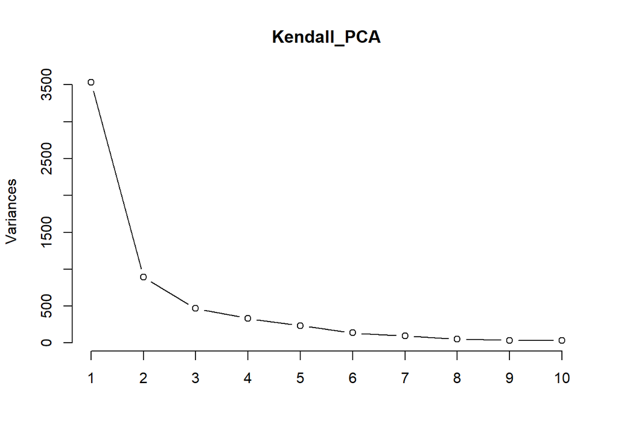

```r
plot(Kendall_PCA, type = "l")
```

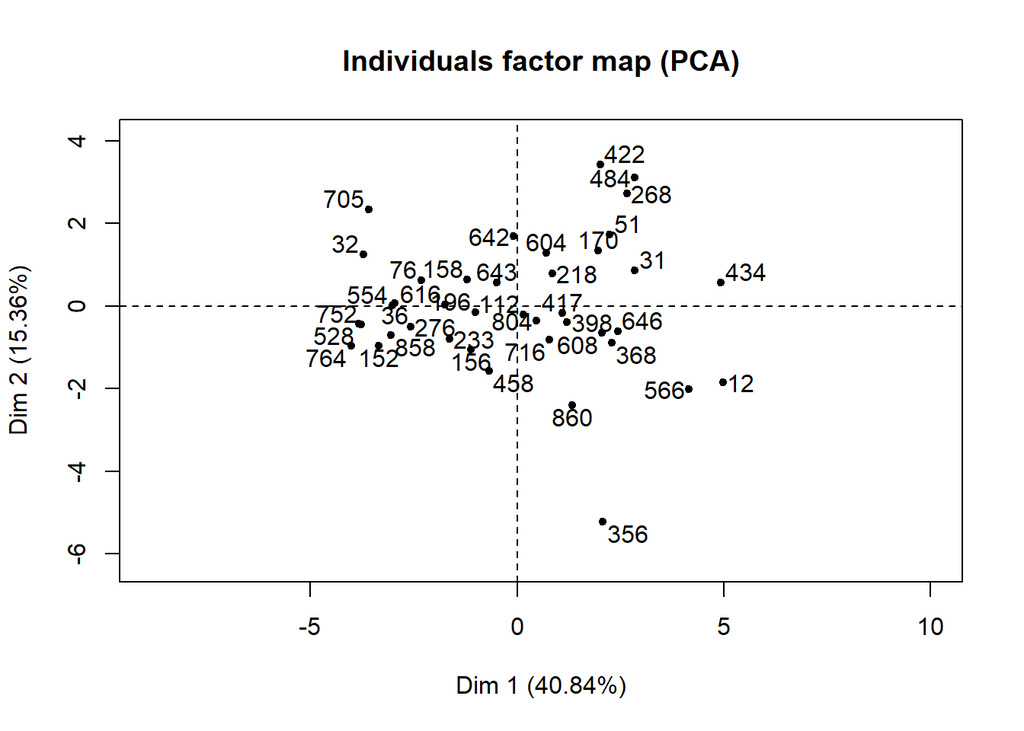

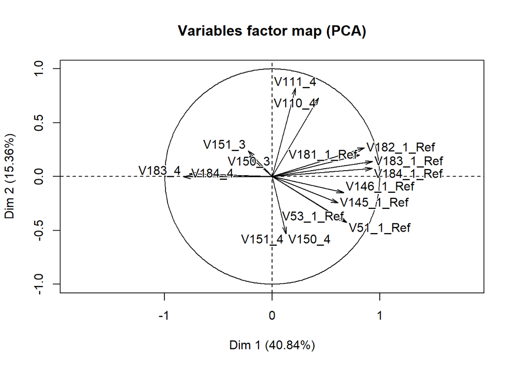

```
## **Results for the Principal Component Analysis (PCA)**
## The analysis was performed on 40 individuals, described by 16 variables
## *The results are available in the following objects:
##
##    name               description
## 1  "$eig"             "eigenvalues"
## 2  "$var"             "results for the variables"
## 3  "$var$coord"       "coord. for the variables"
## 4  "$var$cor"         "correlations variables - dimensions"
## 5  "$var$cos2"        "cos2 for the variables"
## 6  "$var$contrib"     "contributions of the variables"
## 7  "$ind"             "results for the individuals"
## 8  "$ind$coord"       "coord. for the individuals"
## 9  "$ind$cos2"        "cos2 for the individuals"
## 10 "$ind$contrib"     "contributions of the individuals"
## 11 "$call"            "summary statistics"
## 12 "$call$centre"     "mean of the variables"
## 13 "$call$ecart.type" "standard error of the variables"
## 14 "$call$row.w"      "weights for the individuals"
## 15 "$call$col.w"      "weights for the variables"
```

```r
PCA(WVS_Data_Precentages5_Kendall)
```

# Varaible Reduction: Kendall Rank Correlations - PCA Loadings

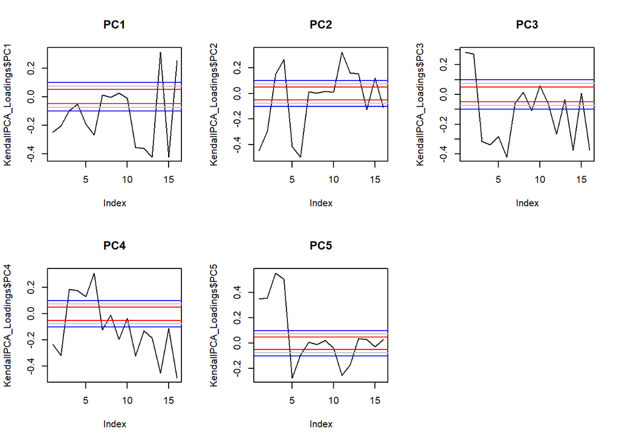

```r
#Loadings have variables as rows
KendallPCA_Loadings <- round(Kendall_PCA$rotation [,c(1:5)], 3)
KendallPCA_Loadings <- as.data.frame(KendallPCA_Loadings)

par(mfrow=c(2,3))

plot(KendallPCA_Loadings$PC1, type = "l", main = "PC1")
abline(h=0.05, col="red")
abline(h=-0.05, col="red")
abline(h=0.075, col="grey")
abline(h=-0.075, col="grey")
abline(h=0.1, col="blue")
abline(h=-0.1, col="blue")

plot(KendallPCA_Loadings$PC2, type = "l", main = "PC2")
abline(h=0.05, col="red")
abline(h=-0.05, col="red")
abline(h=0.075, col="grey")
abline(h=-0.075, col="grey")
abline(h=0.1, col="blue")
abline(h=-0.1, col="blue")

plot(KendallPCA_Loadings$PC3, type = "l", main = "PC3")
abline(h=0.05, col="red")
abline(h=-0.05, col="red")
abline(h=0.075, col="grey")
abline(h=-0.075, col="grey")
abline(h=0.1, col="blue")
abline(h=-0.1, col="blue")

plot(KendallPCA_Loadings$PC4, type = "l", main = "PC4")
abline(h=0.05, col="red")
abline(h=-0.05, col="red")
abline(h=0.075, col="grey")
abline(h=-0.075, col="grey")
abline(h=0.1, col="blue")
abline(h=-0.1, col="blue")

plot(KendallPCA_Loadings$PC5, type = "l", main = "PC5")
abline(h=0.05, col="red")
abline(h=-0.05, col="red")
abline(h=0.075, col="grey")
abline(h=-0.075, col="grey")
abline(h=0.1, col="blue")
abline(h=-0.1, col="blue")
```

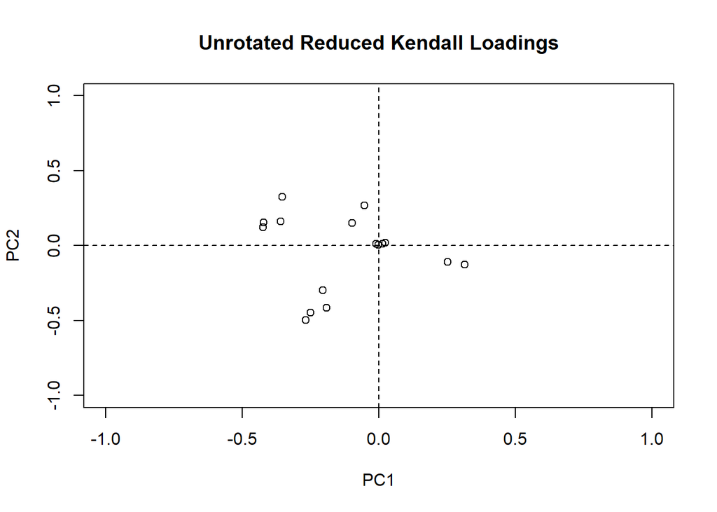

```r
plot(KendallPCA_Loadings[,c(1,2)], xlim = c(-1, 1), ylim = c(-1, 1), main = "Unrotated Reduced Kendall Loadings")
abline(v = 0, h = 0, lty = 2)
```

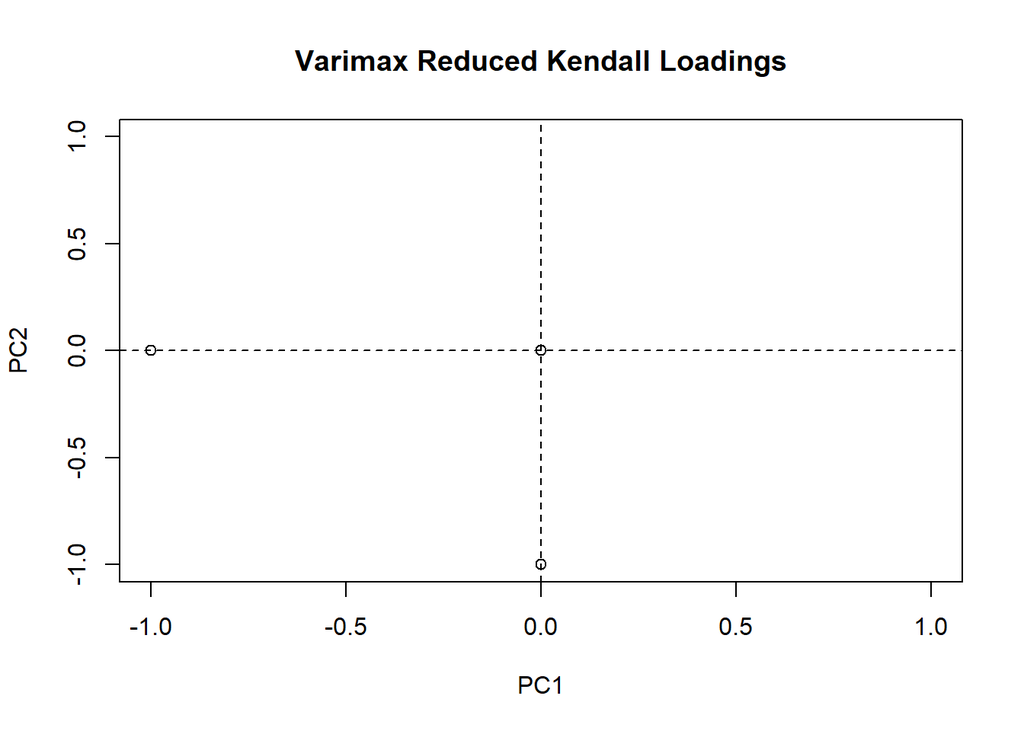

```r
Kendall.Varimax <-varimax(Kendall_PCA$rotation)
#try regressions with national data and then try to reduce the sample to older, educated, males - see if that helps clarify results.
Kendall.Varimax.Loadings <- Kendall.Varimax$loadings[,c(1:6)]

plot(Kendall.Varimax.Loadings[,c(1,2)], xlim = c(-1, 1), ylim = c(-1, 1), main = "Varimax Reduced Kendall Loadings")
abline(v = 0, h = 0, lty = 2)
```

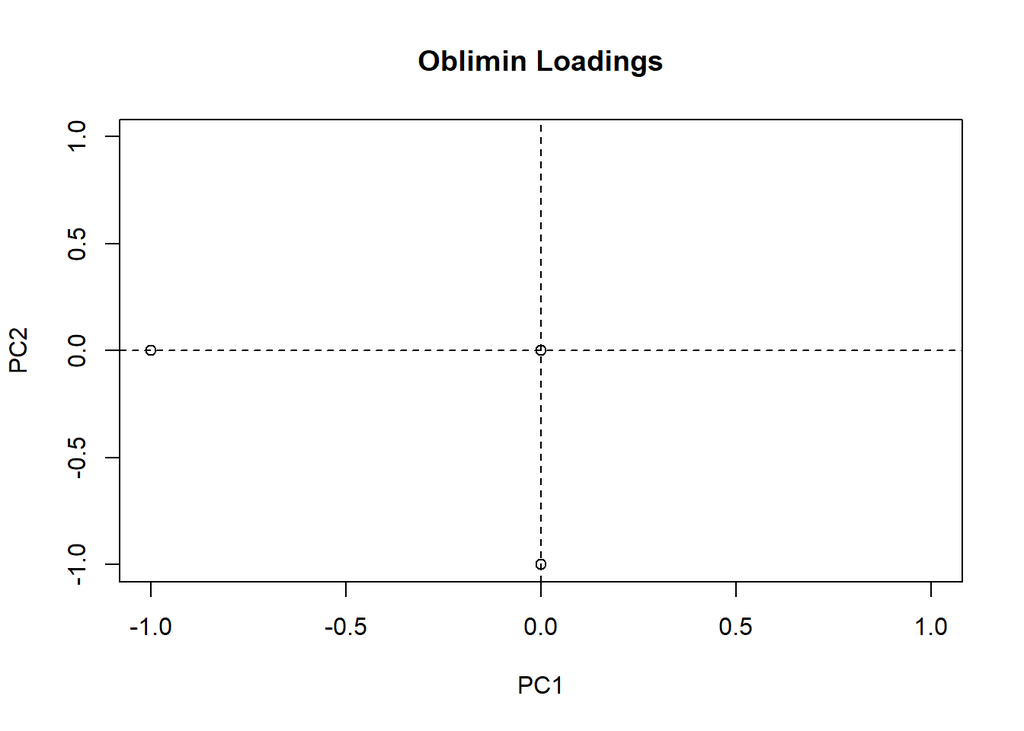

```r
Kendall.Oblimin <- oblimin(Kendall_PCA$rotation)
Kendall.Oblimin.Loadings <- Kendall.Oblimin$loadings

plot(Kendall.Oblimin.Loadings[,c(1,2)], xlim = c(-1, 1), ylim = c(-1, 1), main = "Oblimin Loadings")
abline(v = 0, h = 0, lty = 2)
```

We can add the descriptions to get a sense of what the components are describing.

```r
Kendall.Correlation.Variable.Descriptions <- read.csv("Kendall_Correlation_Variable_Descriptions.csv")

V1_Names <- merge(Sig_Correlations_Clean, Kendall.Correlation.Variable.Descriptions, by.x = "V1", by.y = "VariablestoKeep")

V1_Names <- V1_Names[c("V1", "Description", "R_squared", "V2")]
V2_Names <- merge(V1_Names, Kendall.Correlation.Variable.Descriptions, by.x = "V2", by.y = "VariablestoKeep")
V2_Names <- V2_Names[c("V1", "Description.x", "R_squared", "V2", "Description.y")]

Kendall_PCA_Loadings_Description <- merge(KendallPCA_Loadings ,
                                     Kendall.Correlation.Variable.Descriptions, by.x = 0,
                                     by.y = "VariablestoKeep" )

Kendall_PCA_Loadings_Description<-  Kendall_PCA_Loadings_Description[,c("Row.names", "Description",
                                                               "PC1", "PC2", "PC3", "PC4", "PC4")]
```

## Analysis at an Invidiual Level: Variable Reduction at Indvidual Level - NOT COMPLETE

Another option is to using the data at the individual level. We could use a nominal logistic model to estimate factors of categorical varaibles. First developed by Bock, the nominal model is accessible for large datasets through the MIRT package and mirt function in R (developed by Phil Chalmers). This anlaysis is shown in another R file. It has been able to extract 1 and 2 factor models and is currently working on a three factor model.